# Optional Homework 3: Solution

We would like to fit the following model:

$$\log(\text{signal}_i) = \beta_0 + \beta_1\text{group}_i +
\beta_2\text{dose}_i + \beta_3\text{group}_i\text{dose}_i + \epsilon_i$$

```r
library(idarps)
data("HP13Cbicarbonate")

# Log transform
HP13Cbicarbonate$log_signal = log(HP13Cbicarbonate$signal)

# Fit the model
mod = lm(log_signal ~ group*dose, data = HP13Cbicarbonate)
summary(mod)
```

```
##
## Call:
## lm(formula = log_signal ~ group * dose, data = HP13Cbicarbonate)
##
## Residuals:
##      Min       1Q   Median       3Q      Max
## -0.89085 -0.20300 -0.07998  0.24502  1.20449
##
## Coefficients:
##               Estimate Std. Error t value Pr(>|t|)
## (Intercept)    -3.1788     0.1722 -18.460  < 2e-16 ***
## groupFed        0.7468     0.2354   3.172  0.00365 **
## dose           -0.2266     1.6014  -0.142  0.88846
## groupFed:dose  -4.2948     2.0360  -2.109  0.04398 *
## ---
## Signif. codes:  0 '***' 0.001 '**' 0.01 '*' 0.05 '.' 0.1 ' ' 1
##
## Residual standard error: 0.4704 on 28 degrees of freedom
## Multiple R-squared:  0.3906, Adjusted R-squared:  0.3253
## F-statistic: 5.982 on 3 and 28 DF,  p-value: 0.002772
```

Next we evaluate graphically the adequacy of this model with the data:

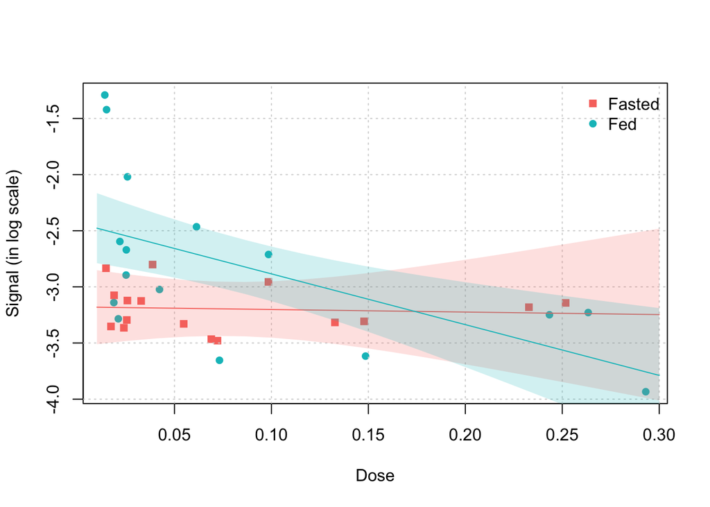

```r
colors = c("#F8766D", "#00BFC4")
plot(HP13Cbicarbonate$dose, HP13Cbicarbonate$log_signal,
     xlab = "Dose", ylab = "Signal (in log scale)",
     col = colors[as.numeric(HP13Cbicarbonate$group == "Fed") + 1],
     pch = 15 + as.numeric(HP13Cbicarbonate$group == "Fed"))
grid()
legend("topright", c("Fasted", "Fed"), col = colors, pch = c(15, 16), bty = "n")

dose_to_predict = seq(0.01, 0.3, length.out = 20)
pred_fasted = predict(mod, data.frame(dose = dose_to_predict, group = rep("Fasted", length(dose_to_predict))), interval = "confidence")
pred_fed = predict(mod, data.frame(dose = dose_to_predict, group = rep("Fed", length(dose_to_predict))), interval = "confidence")

lines(dose_to_predict, pred_fasted[,1], col = "#F8766D")
polygon(c(dose_to_predict, rev(dose_to_predict)), c(pred_fasted[,2], rev(pred_fasted[,3])), col = "#F8766D33", border = NA)

lines(dose_to_predict, pred_fed[,1], col = "#00BFC4")
polygon(c(dose_to_predict, rev(dose_to_predict)), c(pred_fed[,2], rev(pred_fed[,3])), col = "#00BFC433", border = NA)
```

We also construct the model diagnostic graphs for this model as follows:

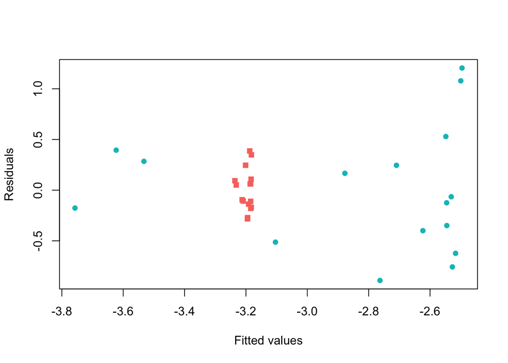

```r
plot(predict(mod), resid(mod),
     xlab = "Fitted values", ylab = "Residuals",
     col = colors[as.numeric(HP13Cbicarbonate$group == "Fed") + 1],
       pch = 15 + as.numeric(HP13Cbicarbonate$group == "Fed"))
```

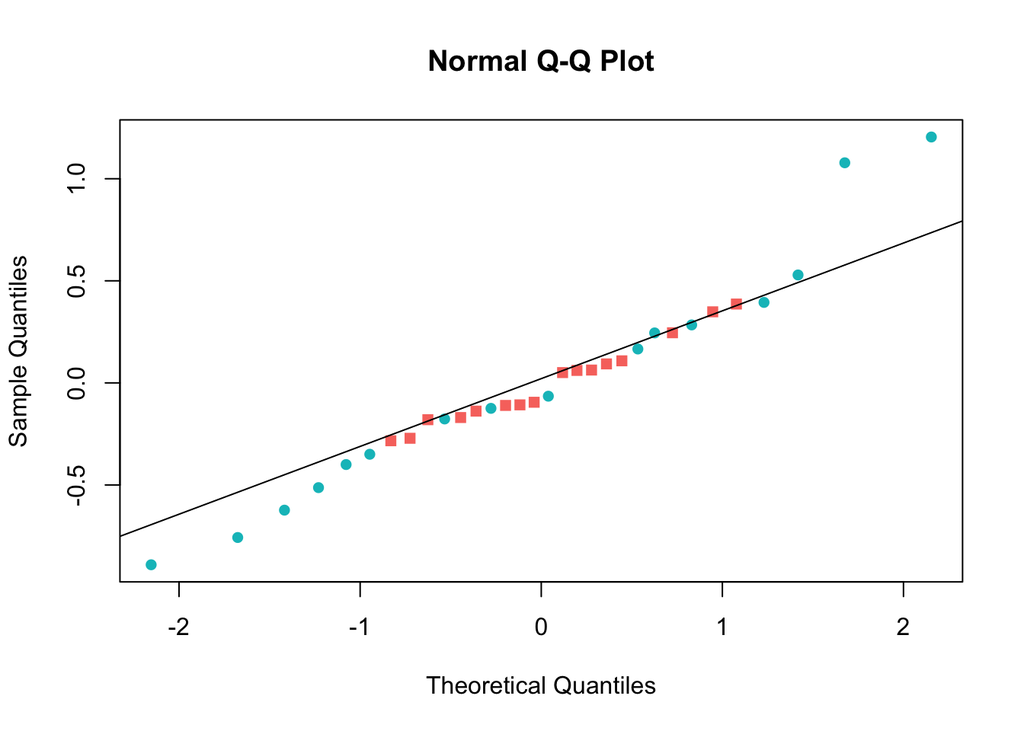

```r
qqnorm(resid(mod),
       col = colors[as.numeric(HP13Cbicarbonate$group == "Fed") + 1],
       pch = 15 + as.numeric(HP13Cbicarbonate$group == "Fed"))
qqline(resid(mod))
```

Now we evaluate the claims of the scientists. We recall the model summary as below:

```r
summary(mod)
```

```
##
## Call:
## lm(formula = log_signal ~ group * dose, data = HP13Cbicarbonate)
##
## Residuals:
##      Min       1Q   Median       3Q      Max
## -0.89085 -0.20300 -0.07998  0.24502  1.20449
##
## Coefficients:
##               Estimate Std. Error t value Pr(>|t|)
## (Intercept)    -3.1788     0.1722 -18.460  < 2e-16 ***
## groupFed        0.7468     0.2354   3.172  0.00365 **
## dose           -0.2266     1.6014  -0.142  0.88846
## groupFed:dose  -4.2948     2.0360  -2.109  0.04398 *
## ---
## Signif. codes:  0 '***' 0.001 '**' 0.01 '*' 0.05 '.' 0.1 ' ' 1
##
## Residual standard error: 0.4704 on 28 degrees of freedom
## Multiple R-squared:  0.3906, Adjusted R-squared:  0.3253
## F-statistic: 5.982 on 3 and 28 DF,  p-value: 0.002772
```

**Claim 2**: “*In the fed group, the variable dose has an impact on the signal (and we expect that the higher is the dose, the lower is the signal)*”, which corresponds to the hypotheses:

$$H_0: \;\; \beta_3 = 0, \;\;\; H_a: \;\;
\beta_3 < 0.$$

The p-value of this test is 0.02199. Therefore, at the 95% confidence level we can reject the null hypothesis and conclude that in the fed group, the higher is the dose, the lower is the signal.